# Female Representatives and Perception of Women as Leaders

Lisa Chu, Nida Haroon, Sophia Ahn, Victoria Ewing

March 12, 2018

# Introduction

In the United States, despite years of effort to increase the level of gender equality, women are underrepresented in leadership positions in the governemnt and in business. In 2014, PEW Research Center conducted a nationally representative phone survey asking respondents how they felt about men and women in leadership positions. We hypothesize that being exposed to women in leadership positions will increase individuals’ perception of women as leaders.

Our research question is as follows: **Does the percentage of female representatives in their state influence people’s perceptions of women as leaders?**

# Data

The data for the outcome variable is from the Gender and Leadership dataset from PEW Research Centre. The final sample includes 1,835 adults, 18+ residing in the US and was conducted between November 12-21, 2014. The questionnaire was administered in both English and Spanish.

The data for the representatives is from the National Conference of State Legislatures. The two datasets were cleaned and merged to keep only the variables of interest.

The outcome variable is Question 5a on the PEW Survey which asks the respondents, ‘Which one of the following statements comes closest to your opinion about as POLITICAL LEADERS?’ 1. Men generally make better political leaders than women 2. In general, women and men make equally good political leaders 3. Women generally make better political leaders than men

# Summary Statistics

```r
link='https://github.com/lmchu1/WomenLeaders599/raw/master/preprocessed_data.csv'

womendata<-read.csv(link,stringsAsFactors = F)

pander(names(womendata))
```

*age*, *educ*, *race*, *gender*, *hhincome*, *employment*, *party*, *opinion_leaders*, *state* and *perc_women*

We hypothesize that respondents’ gender, age, level of education, income level, and political party all likely impact their perception of women as political leaders.

```r
pander(summary(womendata))
```

Table continues below

| age | educ | race | gender | hhincome |
| --- | --- | --- | --- | --- |
| Min. :1.000 | Min. : 1.00 | Min. :1.000 | Min. :0.0000 | Min. : 1.0 |
| 1st Qu.:3.000 | 1st Qu.: 9.00 | 1st Qu.:1.000 | 1st Qu.:0.0000 | 1st Qu.: 9.0 |
| Median :4.000 | Median :10.00 | Median :1.000 | Median :1.0000 | Median :13.0 |
| Mean :4.043 | Mean :10.21 | Mean :1.623 | Mean :0.5016 | Mean :12.2 |
| 3rd Qu.:5.000 | 3rd Qu.:12.00 | 3rd Qu.:2.000 | 3rd Qu.:1.0000 | 3rd Qu.:16.0 |
| Max. :7.000 | Max. :14.00 | Max. :5.000 | Max. :1.0000 | Max. :19.0 |
| NA | NA | NA | NA | NA |

Table continues below

| employment | party | opinion_leaders | state |
| --- | --- | --- | --- |
| Min. :1.000 | Min. :1.000 | Min. :1.000 | Length:1830 |
| 1st Qu.:1.000 | 1st Qu.:2.000 | 1st Qu.:2.000 | Class :character |
| Median :2.000 | Median :5.000 | Median :2.000 | Mode :character |
| Mean :2.945 | Mean :4.146 | Mean :1.949 | NA |
| 3rd Qu.:5.000 | 3rd Qu.:6.000 | 3rd Qu.:2.000 | NA |
| Max. :7.000 | Max. :7.000 | Max. :3.000 | NA |
| NA | NA | NA’s :23 | NA |

| perc_women |
| --- |
| Min. :0.1250 |
| 1st Qu.:0.2000 |
| Median :0.2350 |
| Mean :0.2402 |
| 3rd Qu.:0.2670 |
| Max. :0.4100 |
| NA |

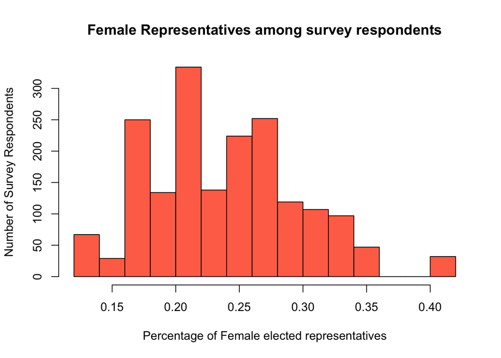

```r
hist(womendata$perc_women,
     xlab= 'Percentage of Female elected representatives' , ylab='Number of Survey Respondents',
     main='Female Representatives among survey respondents',
       col='coral1'
     )
```

Here we examine the distribution of “percent of female elected representatives” among the survey respondents. Because we are examining state legistures, all indivduals from the same state have the smale percent of female representatives. All individuals The percentage of female representatives in 2014 ranged from 12.5% to 41%.

Looking at a map of the United States, we can see that certain states have much higher percentages of female than others:

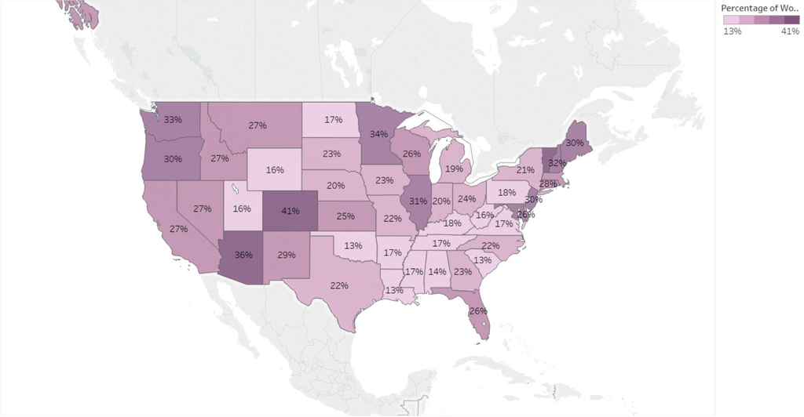

*Map of % of Female Representatives by State*

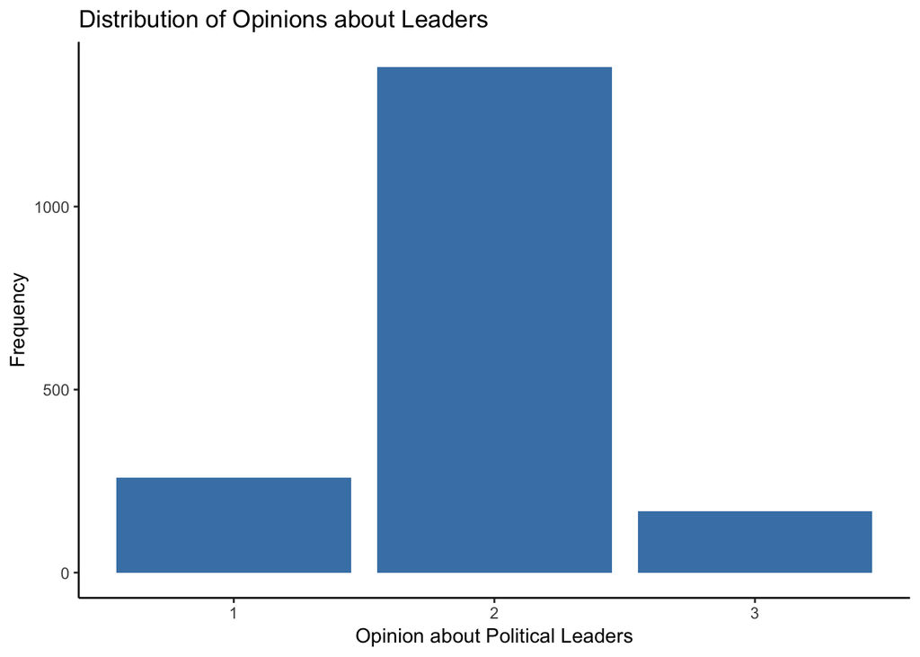

```r
ggplot(womendata, aes(opinion_leaders))+
       geom_bar(fill='steelblue') + theme_classic() +
  xlab('Opinion about Political Leaders') + ylab('Frequency') + ggtitle('Distribution of Opinions about Leaders')
```

*Key:* 1. *Men generally make better political leaders than women* 2. *In general, women and men make equally good political leaders* 3. *Women generally make better political leaders than men*

The majority of respondents believe that women and men make equally good political leaders. However, a greater number believe that men make better political leaders than believe that women make better political leaders.

# Why a Linear Regression Isn’t Appropriate

```r
Linreg=lm(opinion_leaders ~ perc_women + age + hhincome + gender + educ + race + employment + party, data=womendata)
```

A linear regression is not appropriate for this data because the outcome variable of interest is an ordered categorical variable.

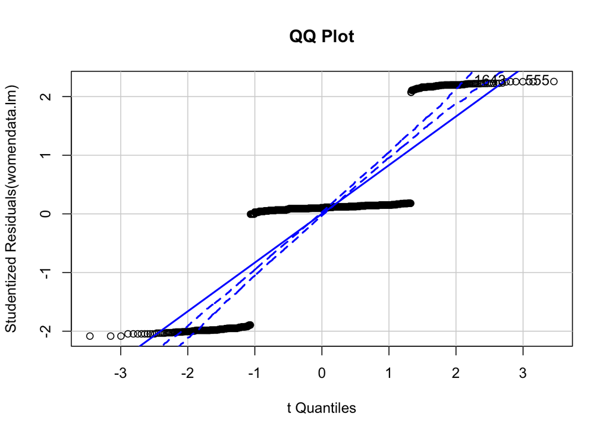

```
## [1]  555 1643
```

```r
womendata.lm=lm(opinion_leaders~perc_women, data=womendata)

qqPlot(womendata.lm, main="QQ Plot")
```

The above graph of the residuals is a good visual representation of why the linear model is inappropriate

```r
pander(summary(Linreg))
```

|  | Estimate | Std. Error | t value | Pr(>\|t\|) |
| --- | --- | --- | --- | --- |
| **(Intercept)** | 1.416 | 0.08249 | 17.16 | 2.887e-61 |
| **perc_women** | 0.2262 | 0.1888 | 1.198 | 0.2312 |
| **age** | 0.007649 | 0.006789 | 1.127 | 0.26 |
| **hhincome** | 0.002045 | 0.002896 | 0.7059 | 0.4803 |
| **gender** | 0.09271 | 0.02221 | 4.174 | 3.142e-05 |
| **educ** | 0.01508 | 0.005778 | 2.61 | 0.009132 |
| **race** | -0.003688 | 0.009956 | -0.3704 | 0.7111 |
| **employment** | -0.001433 | 0.005455 | -0.2627 | 0.7928 |
| **party** | 0.05601 | 0.005327 | 10.51 | 3.906e-25 |

Fitting linear model: opinion_leaders ~ perc_women + age + hhincome + gender + educ + race + employment + party

| Observations | Residual Std. Error | $R^2$ | Adjusted $R^2$ |
| --- | --- | --- | --- |
| 1807 | 0.4655 | 0.07542 | 0.0713 |

# Results

```r
results.oprob<-oglmx(opinion_leaders ~ perc_women + educ + age + gender + hhincome + employment + party, data=womendata, link="probit",
     constantMEAN = FALSE, constantSD = FALSE,
     delta=0,threshparam = NULL)

summary(results.oprob)
```

```
## Ordered Probit Regression
## Log-Likelihood: -1199.859
## No. Iterations: 5
## McFadden's R2: 0.05680872
## AIC: 2417.718
##              Estimate Std. error t value  Pr(>|t|)
## perc_women  0.5850101  0.5077565  1.1521  0.249261
## educ        0.0428058  0.0152874  2.8001  0.005109 **
## age         0.0206606  0.0181351  1.1393  0.254595
## gender      0.2579358  0.0605797  4.2578 2.065e-05 ***
## hhincome    0.0059950  0.0078522  0.7635  0.445178
## employment -0.0033745  0.0148140 -0.2278  0.819810
## party       0.1541756  0.0148495 10.3825 < 2.2e-16 ***
## ----- Threshold Parameters -----
##                  Estimate Std. error t value Pr(>|t|)
## Threshold (1->2)  0.35976    0.21327  1.6869  0.09163 .
## Threshold (2->3)  2.91219    0.22571 12.9025  < 2e-16 ***
## ---
## Signif. codes:  0 '***' 0.001 '**' 0.01 '*' 0.05 '.' 0.1 ' ' 1
```

As we are using the ordered probit model, we need to see the marginal effects to see the effect of our independent variables on our dependent variable.

```r
margins.oglmx(results.oprob,ascontinuous = TRUE)
```

```
## Marginal Effects on Pr(Outcome==1)
##             Marg. Eff Std. error  t value  Pr(>|t|)
## perc_women -0.1226020  0.1064489  -1.1517  0.249426
## educ       -0.0089709  0.0032065  -2.7977  0.005146 **
## age        -0.0043299  0.0038024  -1.1387  0.254818
## gender     -0.0540562  0.0127228  -4.2488 2.149e-05 ***
## hhincome   -0.0012564  0.0016456  -0.7635  0.445171
## employment  0.0007072  0.0031046   0.2278  0.819812
## party      -0.0323109  0.0031537 -10.2456 < 2.2e-16 ***
## ------------------------------------
## Marginal Effects on Pr(Outcome==2)
##              Marg. Eff  Std. error t value  Pr(>|t|)
## perc_women  0.03717293  0.03320268  1.1196  0.262894
## educ        0.00271998  0.00112534  2.4170  0.015648 *
## age         0.00131282  0.00118514  1.1077  0.267975
## gender      0.01638985  0.00515924  3.1768  0.001489 **
## hhincome    0.00038093  0.00050528  0.7539  0.450904
## employment -0.00021442  0.00094227 -0.2276  0.819990
## party       0.00979668  0.00226251  4.3300 1.491e-05 ***
## ------------------------------------
## Marginal Effects on Pr(Outcome==3)
##              Marg. Eff  Std. error t value  Pr(>|t|)
## perc_women  0.08542902  0.07421773  1.1511  0.249708
## educ        0.00625093  0.00224413  2.7855  0.005345 **
## age         0.00301707  0.00265120  1.1380  0.255121
## gender      0.03766636  0.00894544  4.2107 2.546e-05 ***
## hhincome    0.00087545  0.00114695  0.7633  0.445294
## employment -0.00049277  0.00216349 -0.2278  0.819826
## party       0.02251426  0.00230512  9.7671 < 2.2e-16 ***
## ---
## Signif. codes:  0 '***' 0.001 '**' 0.01 '*' 0.05 '.' 0.1 ' ' 1
```

Our results show that education, gender, and party have significant effects at the 95% confidence level on a person’s opinions on political leaders. Regarding our primary variable of interest, an 1-unit increase in the percentage of elected women representatives in the respondent’s state of residence insignificantly decreases the likelihood of believing that men generally make better political leaders than woman by roughly 12%.

# Heteroskedasticity

```r
results.oprobhet<-oglmx(opinion_leaders ~ perc_women + educ + age + gender + hhincome + employment + party, data=womendata,constantMEAN= FALSE, constantSD= FALSE,threshparam=NULL)

summary(results.oprobhet)
```

```
## Ordered Probit Regression
## Log-Likelihood: -1199.859
## No. Iterations: 8
## McFadden's R2: 0.05680872
## AIC: 2419.718
## ----- Mean Equation ------
##               Estimate  Std. error t value Pr(>|t|)
## perc_women  0.06539707  0.51024928  0.1282   0.8980
## educ        0.00478583  0.03715322  0.1288   0.8975
## age         0.00230986  0.01802681  0.1281   0.8980
## gender      0.02884132  0.22379035  0.1289   0.8975
## hhincome    0.00067029  0.00527199  0.1271   0.8988
## employment -0.00037755  0.00336583 -0.1122   0.9107
## party       0.01723933  0.13371577  0.1289   0.8974
## ----- SD Equation ------
##                  Estimate Std. error t value Pr(>|t|)
## Threshold (1->2)  -2.1909     7.7560 -0.2825   0.7776
## ----- Threshold Parameters -----
##                  Estimate Std. error t value Pr(>|t|)
## Threshold (2->3) 0.040213   0.312681  0.1286   0.8977
## NA               0.325620   2.525510  0.1289   0.8974
```

```r
results.oprobhet<-oglmx(opinion_leaders ~ perc_women + educ + age + gender + hhincome + employment + party, data=womendata,constantMEAN= FALSE, constantSD= FALSE,threshparam=NULL)

summary(results.oprobhet$Hetero)
```

```
##    Mode   FALSE
## logical       1
```

# Multi-collinearity

```r
pander(vif(Linreg) > 3 )
```

| perc_women | age | hhincome | gender | educ | race | employment | party |
| --- | --- | --- | --- | --- | --- | --- | --- |
| FALSE | FALSE | FALSE | FALSE | FALSE | FALSE | FALSE | FALSE |

We tested for multicollinearity to see if our independent variables are perfect linear functions of each other. If there is multicollinearity, then our model will not work because we cannot simultaneously get estimates for independent variable that are perfect linear functions. Fortunately, our test resulted in “false.”